# HelmNet_Classification

Image Classification model

With Helmet/ Without Helmet

[figure not shown]

HelmNet

# **Problem Statement**

## **Business Context**

Workplace safety in hazardous environments like construction sites and industrial plants is crucial to prevent accidents and injuries. One of the most important safety measures is ensuring workers wear safety helmets, which protect against head injuries from falling objects and machinery. Non-compliance with helmet regulations increases the risk of serious injuries or fatalities, making effective monitoring essential, especially in large-scale operations where manual oversight is prone to errors and inefficiency.

To overcome these challenges, SafeGuard Corp plans to develop an automated image analysis system capable of detecting whether workers are wearing safety helmets. This system will improve safety enforcement, ensuring compliance and reducing the risk of head injuries. By automating helmet monitoring, SafeGuard aims to enhance efficiency, scalability, and accuracy, ultimately fostering a safer work environment while minimizing human error in safety oversight.

## **Objective**

As a data scientist at SafeGuard Corp, you are tasked with developing an image classification model that classifies images into one of two categories:

- **With Helmet:** Workers wearing safety helmets.
- **Without Helmet:** Workers not wearing safety helmets.

## **Data Description**

- **With Helmet:** 311 images showing workers wearing helmets.
- **Without Helmet:** 320 images showing workers not wearing helmets.

**Dataset Characteristics:**

- **Variations in Conditions:** Images include diverse environments such as construction sites, factories, and industrial settings, with variations in lighting, angles, and worker postures to simulate real-world conditions.
- **Worker Activities:** Workers are depicted in different actions such as standing, using tools, or moving, ensuring robust model learning for various scenarios.

# **Installing and Importing the Necessary Libraries**

```python
!pip install tensorflow[and-cuda] numpy==1.25.2 -q
```

[output not shown]

```python
import tensorflow as tf
print("Num GPUs Available:", len(tf.config.list_physical_devices('GPU')))
print(tf.__version__)
```

```
Num GPUs Available: 1
2.17.1
```

**Note:**

- After running the above cell, kindly restart the notebook kernel (for Jupyter Notebook) or runtime (for Google Colab) and run all cells sequentially from the next cell.
- On executing the above line of code, you might see a warning regarding package dependencies. This error message can be ignored as the above code ensures that all necessary libraries and their dependencies are maintained to successfully execute the code in this notebook.

```python
import os
import random
import numpy as np                                                                               # Importing numpy for Matrix Operations
import pandas as pd
import seaborn as sns
import matplotlib.image as mpimg                                                                              # Importing pandas to read CSV files
import matplotlib.pyplot as plt                                                                  # Importting matplotlib for Plotting and visualizing images
import math                                                                                      # Importing math module to perform mathematical operations
import cv2


# Tensorflow modules
import keras
import tensorflow as tf
from tensorflow.keras.preprocessing.image import ImageDataGenerator                              # Importing the ImageDataGenerator for data augmentation
from tensorflow.keras.models import Sequential                                                   # Importing the sequential module to define a sequential model
from tensorflow.keras.layers import Dense,Dropout,Flatten,Conv2D,MaxPooling2D,BatchNormalization # Defining all the layers to build our CNN Model
from tensorflow.keras.optimizers import Adam,SGD                                                 # Importing the optimizers which can be used in our model
from sklearn import preprocessing                                                                # Importing the preprocessing module to preprocess the data
from sklearn.model_selection import train_test_split                                             # Importing train_test_split function to split the data into train and test
from sklearn.metrics import confusion_matrix
from tensorflow.keras.models import Model
from keras.applications.vgg16 import VGG16                                               # Importing confusion_matrix to plot the confusion matrix

# Display images using OpenCV
from google.colab.patches import cv2_imshow

#Imports functions for evaluating the performance of machine learning models
from sklearn.metrics import confusion_matrix, f1_score,accuracy_score, recall_score, precision_score, classification_report
from sklearn.metrics import mean_squared_error as mse                                                 # Importing cv2_imshow from google.patches to display images

# Ignore warnings
import warnings
warnings.filterwarnings('ignore')
```

```python
# Set the seed using keras.utils.set_random_seed. This will set:
# 1) `numpy` seed
# 2) backend random seed
# 3) `python` random seed
tf.keras.utils.set_random_seed(812)
```

# **Data Overview**

## Loading the data

```python
# Uncomment and run the following code in case Google Colab is being used
# from google.colab import drive
# drive.mount('/content/drive')
```

```python
# Load the image file of the dataset
images = np.load('images.npy')

# Load the labels file of the dataset
labels = pd.read_csv('Labels.csv')
```

```python
print(images.shape)
print(labels.shape)
```

```
(631, 200, 200, 3)
(631, 1)
```

The width and height of the images in pixels are 200

It is a RGB image

# **Exploratory Data Analysis**

### Plot random images from each of the classes and print their corresponding labels.

[figure not shown]

```python
helmet_indices = np.where(labels == 1)[0]  # Indices of images with helmets
no_helmet_indices = np.where(labels == 0)[0]  # Indices of images without helmets

# Select one image from each class
helmet_img = images[np.random.choice(helmet_indices)]
no_helmet_img = images[np.random.choice(no_helmet_indices)]

# Plot the images
fig, axes = plt.subplots(1, 2, figsize=(8, 4))

# Display "With Helmet" image
axes[0].imshow(helmet_img)
axes[0].set_title("Worker WITH Helmet")
axes[0].axis('off')

# Display "Without Helmet" image
axes[1].imshow(no_helmet_img)
axes[1].set_title("Worker WITHOUT Helmet")
axes[1].axis('off')

# Show the plots
plt.tight_layout()
plt.show()
```

## Checking for class imbalance

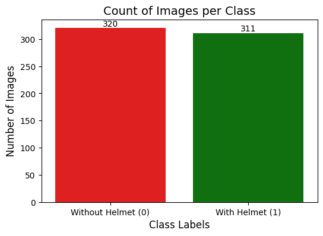

```python
# Create a count plot
plt.figure(figsize=(6, 4))
ax = sns.countplot(x=labels.iloc[:, 0], palette=['red', 'green'])

# Add exact counts on top of bars
for p in ax.patches:
    ax.annotate(f'{int(p.get_height())}', (p.get_x() + p.get_width() / 2, p.get_height()),
                ha='center', va='bottom', fontsize=10, )

# Add labels
plt.xlabel("Class Labels", fontsize=12)
plt.ylabel("Number of Images", fontsize=12)
plt.title("Count of Images per Class", fontsize=14)
plt.xticks(ticks=[0, 1], labels=["Without Helmet (0)", "With Helmet (1)"])  # Rename x-axis labels

# Show plot
plt.show()
```

- The classes are balanced.

# **Data Preprocessing**

## Converting images to grayscale

[figure not shown]

```python
images_gray = []
for i in range(len(images)):
    img_gray = cv2.cvtColor(images[i], cv2.COLOR_BGR2GRAY)  # Convert to grayscale
    images_gray.append(img_gray)

# Display a sample grayscale image
n = 6
cv2_imshow(images_gray[n])
```

### Splitting the dataset

- As we have less images in our dataset, we will only use 10% of our data for testing, 10% of our data for validation and 80% of our data for training.
- We are using the train_test_split() function from scikit-learn. Here, we split the dataset into three parts, train,test and validation.

```python
from sklearn.model_selection import train_test_split
X_train, X_temp, y_train, y_temp = train_test_split(np.array(images),labels , test_size=0.2, random_state=42,stratify=labels)
X_val, X_test, y_val, y_test = train_test_split(X_temp,y_temp , test_size=0.5, random_state=42,stratify=y_temp)
```

```python
print(X_train.shape,y_train.shape)
print(X_val.shape,y_val.shape)
print(X_test.shape,y_test.shape)
```

```
(504, 200, 200, 3) (504, 1)
(63, 200, 200, 3) (63, 1)
(64, 200, 200, 3) (64, 1)
```

### Data Normalization

Since the **image pixel values range from 0-255**, our method of normalization here will be **scaling** - we shall **divide all the pixel values by 255 to standardize the images to have values between 0-1.**

```python
# Normalizing the image pixels
X_train_normalized = X_train.astype('float32')/255.0
X_val_normalized = X_val.astype('float32')/255.0
X_test_normalized = X_test.astype('float32')/255.0
```

# **Model Building**

## Model Evaluation Criterion

**Labels:**

- **With Helmet:** Workers who are wearing safety helmets as 1.
- **Without Helmet:** Workers who are not wearing safety helmets as 0.

**Which case is important ?**

1️⃣ **False Positive (FP)**: Predicts "With Helmet" when actually "Without Helmet" → Dangerous! 🚨

**Risk**: Undetected safety violations can lead to serious injuries.

2️⃣ **False Negative (FN)**: Predicts "Without Helmet" when actually "With Helmet" → Less severe.

**Impact**: Worker gets unnecessary warnings but stays safe.

**How to reduce False Positive ?**

**Precision= TP/(TP+FP)**

To reduce false positives, we need to focus on improving precision, which is the metric we have chosen.

## Utility Functions

```python
# defining a function to compute different metrics to check performance of a classification model built using statsmodels
def model_performance_classification(model, predictors, target):
    """
    Function to compute different metrics to check classification model performance

    model: classifier
    predictors: independent variables
    target: dependent variable
    """

    # checking which probabilities are greater than threshold
    pred = model.predict(predictors).reshape(-1)>0.5

    target = target.to_numpy().reshape(-1)


    acc = accuracy_score(target, pred)  # to compute Accuracy
    recall = recall_score(target, pred, average='weighted')  # to compute Recall
    precision = precision_score(target, pred, average='weighted')  # to compute Precision
    f1 = f1_score(target, pred, average='weighted')  # to compute F1-score

    # creating a dataframe of metrics
    df_perf = pd.DataFrame({"Accuracy": acc, "Recall": recall, "Precision": precision, "F1 Score": f1,},index=[0],)

    return df_perf
```

```python
def plot_confusion_matrix(model,predictors,target,ml=False):
    """
    Function to plot the confusion matrix

    model: classifier
    predictors: independent variables
    target: dependent variable
    ml: To specify if the model used is an sklearn ML model or not (True means ML model)
    """

    # checking which probabilities are greater than threshold
    pred = model.predict(predictors).reshape(-1)>0.5

    target = target.to_numpy().reshape(-1)

    # Plotting the Confusion Matrix using confusion matrix() function which is also predefined tensorflow module
    confusion_matrix = tf.math.confusion_matrix(target,pred)
    f, ax = plt.subplots(figsize=(10, 8))
    sns.heatmap(
        confusion_matrix,
        annot=True,
        linewidths=.4,
        fmt="d",
        square=True,
        ax=ax
    )
    plt.show()
```

## Model 1: Simple Convolutional Neural Network (CNN)

Let's build a **CNN Model**.

The model has 2 main parts:

1. **The Feature Extraction layers** which are comprised of convolutional and pooling layers.
2. **The Fully Connected classification layers for prediction.**

```python
# Initializing Model
model_1 = Sequential()

# Convolutional layers with increasing filters
model_1.add(Conv2D(32, (3, 3), activation='relu', padding="same", input_shape=(200, 200, 3)))
model_1.add(MaxPooling2D((4, 4), padding='same'))
model_1.add(Conv2D(6, (3, 3), activation='relu', padding="same"))
model_1.add(MaxPooling2D((4, 4), padding='same'))
model_1.add(Conv2D(2, (1, 1), activation='relu', padding="same"))

# Flatten and Dense layers
model_1.add(Flatten())
model_1.add(Dense(4, activation='relu'))
model_1.add(Dense(1, activation='sigmoid'))  # Binary classification output

# Compile with Adam Optimizer
opt = Adam(learning_rate=0.001)
model_1.compile(optimizer=opt, loss='binary_crossentropy', metrics=["accuracy","Precision"])

# Summary
model_1.summary()
```

```
Model: "sequential"
```

```
┏━━━━━━━━━━━━━━━━━━━━━━━━━━━━━━━━━━━━━━┳━━━━━━━━━━━━━━━━━━━━━━━━━━━━━┳━━━━━━━━━━━━━━━━━┓
┃ Layer (type)                         ┃ Output Shape                ┃         Param # ┃
┡━━━━━━━━━━━━━━━━━━━━━━━━━━━━━━━━━━━━━━╇━━━━━━━━━━━━━━━━━━━━━━━━━━━━━╇━━━━━━━━━━━━━━━━━┩
│ conv2d (Conv2D)                      │ (None, 200, 200, 32)        │             896 │
├──────────────────────────────────────┼─────────────────────────────┼─────────────────┤
│ max_pooling2d (MaxPooling2D)         │ (None, 50, 50, 32)          │               0 │
├──────────────────────────────────────┼─────────────────────────────┼─────────────────┤
│ conv2d_1 (Conv2D)                    │ (None, 50, 50, 6)           │           1,734 │
├──────────────────────────────────────┼─────────────────────────────┼─────────────────┤
│ max_pooling2d_1 (MaxPooling2D)       │ (None, 13, 13, 6)           │               0 │
├──────────────────────────────────────┼─────────────────────────────┼─────────────────┤
│ conv2d_2 (Conv2D)                    │ (None, 13, 13, 2)           │              14 │
├──────────────────────────────────────┼─────────────────────────────┼─────────────────┤
│ flatten (Flatten)                    │ (None, 338)                 │               0 │
├──────────────────────────────────────┼─────────────────────────────┼─────────────────┤
│ dense (Dense)                        │ (None, 4)                   │           1,356 │
├──────────────────────────────────────┼─────────────────────────────┼─────────────────┤
│ dense_1 (Dense)                      │ (None, 1)                   │               5 │
└──────────────────────────────────────┴─────────────────────────────┴─────────────────┘
```

```
 Total params: 4,005 (15.64 KB)
```

```
 Trainable params: 4,005 (15.64 KB)
```

```
 Non-trainable params: 0 (0.00 B)
```

```python
history_1 = model_1.fit(
            X_train_normalized, y_train,
            epochs=10,
            validation_data=(X_val_normalized,y_val),
            shuffle=True,
            batch_size=32,
            verbose=2
)
```

```
16/16 - 11s - 713ms/step - Precision: 0.4872 - accuracy: 0.4861 - loss: 0.6830 - val_Precision: 0.4839 - val_accuracy: 0.4762 - val_loss: 0.6625
16/16 - 1s - 79ms/step - Precision: 0.5201 - accuracy: 0.5456 - loss: 0.6197 - val_Precision: 0.5000 - val_accuracy: 0.5079 - val_loss: 0.6025
16/16 - 1s - 38ms/step - Precision: 0.6064 - accuracy: 0.6806 - loss: 0.5084 - val_Precision: 0.6889 - val_accuracy: 0.7778 - val_loss: 0.4481
16/16 - 1s - 37ms/step - Precision: 0.8131 - accuracy: 0.8869 - loss: 0.3991 - val_Precision: 0.8611 - val_accuracy: 0.9206 - val_loss: 0.3356
16/16 - 1s - 41ms/step - Precision: 0.9502 - accuracy: 0.9742 - loss: 0.2692 - val_Precision: 1.0000 - val_accuracy: 1.0000 - val_loss: 0.2155
16/16 - 0s - 24ms/step - Precision: 0.9763 - accuracy: 0.9861 - loss: 0.1657 - val_Precision: 1.0000 - val_accuracy: 0.9683 - val_loss: 0.1826
16/16 - 0s - 23ms/step - Precision: 0.9879 - accuracy: 0.9881 - loss: 0.1037 - val_Precision: 1.0000 - val_accuracy: 0.9683 - val_loss: 0.1667
16/16 - 0s - 23ms/step - Precision: 0.9763 - accuracy: 0.9861 - loss: 0.0783 - val_Precision: 1.0000 - val_accuracy: 0.9683 - val_loss: 0.0850
16/16 - 1s - 39ms/step - Precision: 0.9841 - accuracy: 0.9901 - loss: 0.0476 - val_Precision: 1.0000 - val_accuracy: 0.9683 - val_loss: 0.1361
16/16 - 0s - 25ms/step - Precision: 0.9801 - accuracy: 0.9861 - loss: 0.0515 - val_Precision: 1.0000 - val_accuracy: 0.9683 - val_loss: 0.0970
```

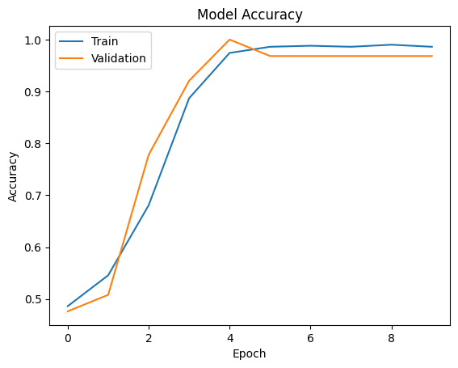

```python
plt.plot(history_1.history['accuracy'])
plt.plot(history_1.history['val_accuracy'])
plt.title('Model Accuracy')
plt.ylabel('Accuracy')
plt.xlabel('Epoch')
plt.legend(['Train', 'Validation'], loc='upper left')
plt.show()
```

```python
model_1_train_perf = model_performance_classification(model_1, X_train_normalized,y_train)

print("Train performance metrics")
print(model_1_train_perf)
```

```
16/16 ━━━━━━━━━━━━━━━━━━━━ 1s 65ms/step
Train performance metrics
   Accuracy    Recall  Precision  F1 Score
0  0.994048  0.994048   0.994056  0.994048
```

```
16/16 ━━━━━━━━━━━━━━━━━━━━ 0s 11ms/step
```

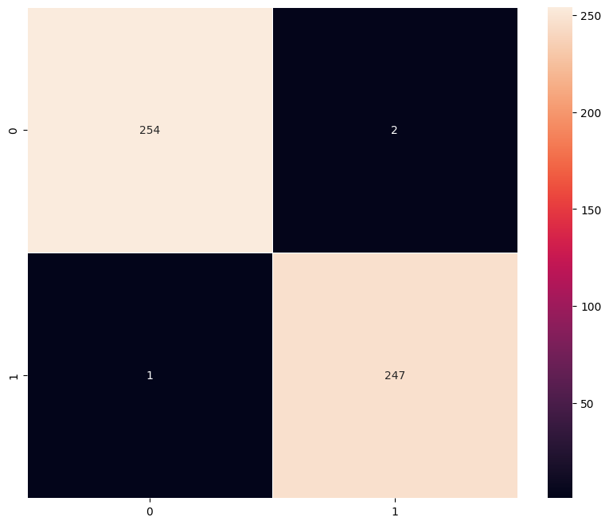

```python
plot_confusion_matrix(model_1,X_train_normalized,y_train)
```

```python
model_1_valid_perf = model_performance_classification(model_1, X_val_normalized,y_val)

print("Validation performance metrics")
print(model_1_valid_perf)
```

```
2/2 ━━━━━━━━━━━━━━━━━━━━ 0s 189ms/step
Validation performance metrics
   Accuracy    Recall  Precision  F1 Score
0  0.968254  0.968254   0.970121  0.968206
```

```
2/2 ━━━━━━━━━━━━━━━━━━━━ 0s 37ms/step
```

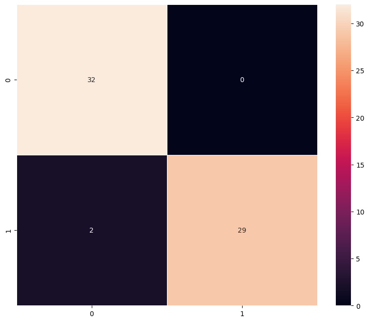

```python
plot_confusion_matrix(model_1,X_val_normalized,y_val)
```

### Vizualizing the predictions

```python
# For index 2
plt.figure(figsize=(2,2))
plt.imshow(X_val[12])
plt.show()
prediction = model_1.predict(X_val_normalized[2].reshape(1,200,200,3))
predicted_label = prediction[0][0]>0.5  # Extract the predicted class label
print('Predicted Label:', 1 if predicted_label else 0)
# Fix indexing issue in y_val
true_label = y_val.iloc[12]
print('True Label:', true_label)

# For index 33
plt.figure(figsize=(2,2))
plt.imshow(X_val[33])
plt.show()
prediction = model_1.predict(X_val_normalized[2].reshape(1,200,200,3))
predicted_label = prediction[0][0]>0.5  # Extract the predicted class label
print('Predicted Label:', 1 if predicted_label else 0)
# Fix indexing issue in y_val
true_label = y_val.iloc[33]
print('True Label:', true_label)
```

[output not shown]

```
1/1 ━━━━━━━━━━━━━━━━━━━━ 0s 144ms/step
Predicted Label: 0
True Label: Label    1
Name: 62, dtype: int64
```

```
1/1 ━━━━━━━━━━━━━━━━━━━━ 0s 140ms/step
Predicted Label: 0
True Label: Label    0
Name: 512, dtype: int64
```

## Model 2: (VGG-16 (Base))

- We will be loading a pre-built architecture - **VGG16**, which was trained on the ImageNet dataset and is the runner-up in the ImageNet competition in 2014.
- For training VGG16, we will directly use the convolutional and pooling layers and freeze their weights i.e. no training will be done on them. For classification, we will add a Flatten and a single dense layer.

```python
vgg_model = VGG16(weights='imagenet',include_top=False,input_shape=(200,200,3))
vgg_model.summary()
```

```
Model: "vgg16"
```

```
┏━━━━━━━━━━━━━━━━━━━━━━━━━━━━━━━━━━━━━━┳━━━━━━━━━━━━━━━━━━━━━━━━━━━━━┳━━━━━━━━━━━━━━━━━┓
┃ Layer (type)                         ┃ Output Shape                ┃         Param # ┃
┡━━━━━━━━━━━━━━━━━━━━━━━━━━━━━━━━━━━━━━╇━━━━━━━━━━━━━━━━━━━━━━━━━━━━━╇━━━━━━━━━━━━━━━━━┩
│ input_layer_1 (InputLayer)           │ (None, 200, 200, 3)         │               0 │
├──────────────────────────────────────┼─────────────────────────────┼─────────────────┤
│ block1_conv1 (Conv2D)                │ (None, 200, 200, 64)        │           1,792 │
├──────────────────────────────────────┼─────────────────────────────┼─────────────────┤
│ block1_conv2 (Conv2D)                │ (None, 200, 200, 64)        │          36,928 │
├──────────────────────────────────────┼─────────────────────────────┼─────────────────┤
│ block1_pool (MaxPooling2D)           │ (None, 100, 100, 64)        │               0 │
├──────────────────────────────────────┼─────────────────────────────┼─────────────────┤
│ block2_conv1 (Conv2D)                │ (None, 100, 100, 128)       │          73,856 │
├──────────────────────────────────────┼─────────────────────────────┼─────────────────┤
│ block2_conv2 (Conv2D)                │ (None, 100, 100, 128)       │         147,584 │
├──────────────────────────────────────┼─────────────────────────────┼─────────────────┤
│ block2_pool (MaxPooling2D)           │ (None, 50, 50, 128)         │               0 │
├──────────────────────────────────────┼─────────────────────────────┼─────────────────┤
│ block3_conv1 (Conv2D)                │ (None, 50, 50, 256)         │         295,168 │
├──────────────────────────────────────┼─────────────────────────────┼─────────────────┤
│ block3_conv2 (Conv2D)                │ (None, 50, 50, 256)         │         590,080 │
├──────────────────────────────────────┼─────────────────────────────┼─────────────────┤
│ block3_conv3 (Conv2D)                │ (None, 50, 50, 256)         │         590,080 │
├──────────────────────────────────────┼─────────────────────────────┼─────────────────┤
│ block3_pool (MaxPooling2D)           │ (None, 25, 25, 256)         │               0 │
├──────────────────────────────────────┼─────────────────────────────┼─────────────────┤
│ block4_conv1 (Conv2D)                │ (None, 25, 25, 512)         │       1,180,160 │
├──────────────────────────────────────┼─────────────────────────────┼─────────────────┤
│ block4_conv2 (Conv2D)                │ (None, 25, 25, 512)         │       2,359,808 │
├──────────────────────────────────────┼─────────────────────────────┼─────────────────┤
│ block4_conv3 (Conv2D)                │ (None, 25, 25, 512)         │       2,359,808 │
├──────────────────────────────────────┼─────────────────────────────┼─────────────────┤
│ block4_pool (MaxPooling2D)           │ (None, 12, 12, 512)         │               0 │
├──────────────────────────────────────┼─────────────────────────────┼─────────────────┤
│ block5_conv1 (Conv2D)                │ (None, 12, 12, 512)         │       2,359,808 │
├──────────────────────────────────────┼─────────────────────────────┼─────────────────┤
│ block5_conv2 (Conv2D)                │ (None, 12, 12, 512)         │       2,359,808 │
├──────────────────────────────────────┼─────────────────────────────┼─────────────────┤
│ block5_conv3 (Conv2D)                │ (None, 12, 12, 512)         │       2,359,808 │
├──────────────────────────────────────┼─────────────────────────────┼─────────────────┤
│ block5_pool (MaxPooling2D)           │ (None, 6, 6, 512)           │               0 │
└──────────────────────────────────────┴─────────────────────────────┴─────────────────┘
```

```
 Total params: 14,714,688 (56.13 MB)
```

```
 Trainable params: 14,714,688 (56.13 MB)
```

```
 Non-trainable params: 0 (0.00 B)
```

```python
# Making all the layers of the VGG model non-trainable. i.e. freezing them
for layer in vgg_model.layers:
    layer.trainable = False
```

```python
model_2 = Sequential()

# Adding the convolutional part of the VGG16 model from above
model_2.add(vgg_model)

# Flattening the output of the VGG16 model because it is from a convolutional layer
model_2.add(Flatten())

# Adding a dense output layer
model_2.add(Dense(1, activation='sigmoid'))
```

```python
opt=Adam()
# Compile model
model_2.compile(optimizer=opt, loss=keras.losses.BinaryCrossentropy(), metrics=["accuracy","Precision"])
```

```python
# Generating the summary of the model
model_2.summary()
```

```
Model: "sequential_2"
```

```
┏━━━━━━━━━━━━━━━━━━━━━━━━━━━━━━━━━━━━━━┳━━━━━━━━━━━━━━━━━━━━━━━━━━━━━┳━━━━━━━━━━━━━━━━━┓
┃ Layer (type)                         ┃ Output Shape                ┃         Param # ┃
┡━━━━━━━━━━━━━━━━━━━━━━━━━━━━━━━━━━━━━━╇━━━━━━━━━━━━━━━━━━━━━━━━━━━━━╇━━━━━━━━━━━━━━━━━┩
│ vgg16 (Functional)                   │ (None, 6, 6, 512)           │      14,714,688 │
├──────────────────────────────────────┼─────────────────────────────┼─────────────────┤
│ flatten_2 (Flatten)                  │ (None, 18432)               │               0 │
├──────────────────────────────────────┼─────────────────────────────┼─────────────────┤
│ dense_3 (Dense)                      │ (None, 1)                   │          18,433 │
└──────────────────────────────────────┴─────────────────────────────┴─────────────────┘
```

```
 Total params: 14,733,121 (56.20 MB)
```

```
 Trainable params: 18,433 (72.00 KB)
```

```
 Non-trainable params: 14,714,688 (56.13 MB)
```

```python
train_datagen = ImageDataGenerator()
```

```python
# Epochs
epochs = 10
# Batch size
batch_size = 8

history_2 = model_2.fit(train_datagen.flow(X_train_normalized,y_train,
                                      batch_size=batch_size,
                                      seed=42,
                                      shuffle=False),
                    epochs=epochs,
                    steps_per_epoch=X_train_normalized.shape[0] // batch_size,
                    validation_data=(X_val_normalized,y_val),
                    verbose=1)
```

```
63/63 ━━━━━━━━━━━━━━━━━━━━ 33s 436ms/step - Precision: 0.9579 - accuracy: 0.9443 - loss: 0.1328 - val_Precision: 1.0000 - val_accuracy: 1.0000 - val_loss: 0.0034
63/63 ━━━━━━━━━━━━━━━━━━━━ 3s 54ms/step - Precision: 1.0000 - accuracy: 1.0000 - loss: 0.0029 - val_Precision: 1.0000 - val_accuracy: 1.0000 - val_loss: 0.0029
63/63 ━━━━━━━━━━━━━━━━━━━━ 5s 54ms/step - Precision: 1.0000 - accuracy: 1.0000 - loss: 0.0013 - val_Precision: 1.0000 - val_accuracy: 1.0000 - val_loss: 0.0020
63/63 ━━━━━━━━━━━━━━━━━━━━ 5s 55ms/step - Precision: 1.0000 - accuracy: 1.0000 - loss: 0.0011 - val_Precision: 1.0000 - val_accuracy: 1.0000 - val_loss: 0.0018
63/63 ━━━━━━━━━━━━━━━━━━━━ 5s 56ms/step - Precision: 1.0000 - accuracy: 1.0000 - loss: 7.6837e-04 - val_Precision: 1.0000 - val_accuracy: 1.0000 - val_loss: 0.0013
63/63 ━━━━━━━━━━━━━━━━━━━━ 4s 56ms/step - Precision: 1.0000 - accuracy: 1.0000 - loss: 6.7733e-04 - val_Precision: 1.0000 - val_accuracy: 1.0000 - val_loss: 0.0012
63/63 ━━━━━━━━━━━━━━━━━━━━ 4s 56ms/step - Precision: 1.0000 - accuracy: 1.0000 - loss: 4.7573e-04 - val_Precision: 1.0000 - val_accuracy: 1.0000 - val_loss: 0.0011
63/63 ━━━━━━━━━━━━━━━━━━━━ 5s 54ms/step - Precision: 1.0000 - accuracy: 1.0000 - loss: 3.4123e-04 - val_Precision: 1.0000 - val_accuracy: 1.0000 - val_loss: 8.9378e-04
63/63 ━━━━━━━━━━━━━━━━━━━━ 3s 55ms/step - Precision: 1.0000 - accuracy: 1.0000 - loss: 2.9312e-04 - val_Precision: 1.0000 - val_accuracy: 1.0000 - val_loss: 8.3541e-04
63/63 ━━━━━━━━━━━━━━━━━━━━ 3s 54ms/step - Precision: 1.0000 - accuracy: 1.0000 - loss: 2.6997e-04 - val_Precision: 1.0000 - val_accuracy: 1.0000 - val_loss: 7.6469e-04
```

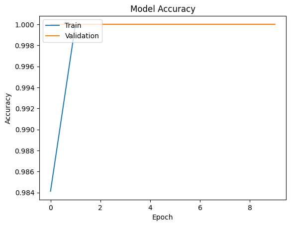

```python
plt.plot(history_2.history['accuracy'])
plt.plot(history_2.history['val_accuracy'])
plt.title('Model Accuracy')
plt.ylabel('Accuracy')
plt.xlabel('Epoch')
plt.legend(['Train', 'Validation'], loc='upper left')
plt.show()
```

```python
model_2_train_perf = model_performance_classification(model_2, X_train_normalized,y_train)

print("Train performance metrics")
print(model_2_train_perf)
```

```
16/16 ━━━━━━━━━━━━━━━━━━━━ 13s 791ms/step
Train performance metrics
   Accuracy  Recall  Precision  F1 Score
0       1.0     1.0        1.0       1.0
```

```python
plot_confusion_matrix(model_2,X_train_normalized,y_train)
```

[output not shown]

```
16/16 ━━━━━━━━━━━━━━━━━━━━ 2s 111ms/step
```

```python
model_2_valid_perf = model_performance_classification(model_2, X_val_normalized,y_val)

print("Validation performance metrics")
print(model_2_valid_perf)
```

```
2/2 ━━━━━━━━━━━━━━━━━━━━ 1s 406ms/step
Validation performance metrics
   Accuracy  Recall  Precision  F1 Score
0       1.0     1.0        1.0       1.0
```

```python
plot_confusion_matrix(model_2,X_val_normalized,y_val)
```

[output not shown]

```
2/2 ━━━━━━━━━━━━━━━━━━━━ 0s 140ms/step
```

### Visualizing the prediction:

```python
# For index 2
plt.figure(figsize=(2,2))
plt.imshow(X_val[12])
plt.show()
prediction = model_2.predict(X_val_normalized[2].reshape(1,200,200,3))
predicted_label = prediction[0][0]>0.5  # Extract the predicted class label
print('Predicted Label:', 1 if predicted_label else 0)
# Fix indexing issue in y_val
true_label = y_val.iloc[12]
print('True Label:', true_label)

# For index 33
plt.figure(figsize=(2,2))
plt.imshow(X_val[33])
plt.show()
prediction = model_2.predict(X_val_normalized[2].reshape(1,200,200,3))
predicted_label = prediction[0][0]>0.5  # Extract the predicted class label
print('Predicted Label:', 1 if predicted_label else 0)
# Fix indexing issue in y_val
true_label = y_val.iloc[33]
print('True Label:', true_label)
```

[output not shown]

```
1/1 ━━━━━━━━━━━━━━━━━━━━ 0s 104ms/step
Predicted Label: 0
True Label: Label    1
Name: 62, dtype: int64
```

```
1/1 ━━━━━━━━━━━━━━━━━━━━ 0s 61ms/step
Predicted Label: 0
True Label: Label    0
Name: 512, dtype: int64
```

## Model 3: (VGG-16 (Base + FFNN))

- We will directly use the convolutional and pooling layers and freeze their weights i.e. no training will be done on them. For classification, we will add a Flatten layer and a Feed Forward Neural Network.

```python
model_3 = Sequential()

# Adding the convolutional part of the VGG16 model from above
model_3.add(vgg_model)

# Flattening the output of the VGG16 model because it is from a convolutional layer
model_3.add(Flatten())

#Adding the Feed Forward neural network
model_3.add(Dense(256,activation='relu'))
model_3.add(Dropout(rate=0.4))
model_3.add(Dense(32,activation='relu'))

# Adding a dense output layer
model_3.add(Dense(1, activation='sigmoid'))
```

```python
opt = Adam()
```

```python
# Compile model
model_3.compile(optimizer=opt,loss=keras.losses.BinaryCrossentropy(), metrics=["accuracy","Precision"])
```

```python
# Generating the summary of the model
model_3.summary()
```

```
Model: "sequential_3"
```

```
┏━━━━━━━━━━━━━━━━━━━━━━━━━━━━━━━━━━━━━━┳━━━━━━━━━━━━━━━━━━━━━━━━━━━━━┳━━━━━━━━━━━━━━━━━┓
┃ Layer (type)                         ┃ Output Shape                ┃         Param # ┃
┡━━━━━━━━━━━━━━━━━━━━━━━━━━━━━━━━━━━━━━╇━━━━━━━━━━━━━━━━━━━━━━━━━━━━━╇━━━━━━━━━━━━━━━━━┩
│ vgg16 (Functional)                   │ (None, 6, 6, 512)           │      14,714,688 │
├──────────────────────────────────────┼─────────────────────────────┼─────────────────┤
│ flatten_3 (Flatten)                  │ (None, 18432)               │               0 │
├──────────────────────────────────────┼─────────────────────────────┼─────────────────┤
│ dense_4 (Dense)                      │ (None, 256)                 │       4,718,848 │
├──────────────────────────────────────┼─────────────────────────────┼─────────────────┤
│ dropout (Dropout)                    │ (None, 256)                 │               0 │
├──────────────────────────────────────┼─────────────────────────────┼─────────────────┤
│ dense_5 (Dense)                      │ (None, 32)                  │           8,224 │
├──────────────────────────────────────┼─────────────────────────────┼─────────────────┤
│ dense_6 (Dense)                      │ (None, 1)                   │              33 │
└──────────────────────────────────────┴─────────────────────────────┴─────────────────┘
```

```
 Total params: 19,441,793 (74.16 MB)
```

```
 Trainable params: 4,727,105 (18.03 MB)
```

```
 Non-trainable params: 14,714,688 (56.13 MB)
```

```python
history_3 = model_3.fit(train_datagen.flow(X_train_normalized,y_train,
                                       batch_size=8,
                                       seed=42,
                                       shuffle=False),
                    epochs=epochs,
                    steps_per_epoch=X_train_normalized.shape[0] // batch_size,
                    validation_data=(X_val_normalized,y_val),
                    verbose=1)
```

```
63/63 ━━━━━━━━━━━━━━━━━━━━ 10s 102ms/step - Precision: 0.8936 - accuracy: 0.9083 - loss: 0.1903 - val_Precision: 1.0000 - val_accuracy: 1.0000 - val_loss: 4.1514e-07
63/63 ━━━━━━━━━━━━━━━━━━━━ 6s 54ms/step - Precision: 0.9779 - accuracy: 0.9830 - loss: 0.0296 - val_Precision: 1.0000 - val_accuracy: 1.0000 - val_loss: 1.3051e-07
63/63 ━━━━━━━━━━━━━━━━━━━━ 3s 55ms/step - Precision: 1.0000 - accuracy: 1.0000 - loss: 6.3318e-06 - val_Precision: 1.0000 - val_accuracy: 1.0000 - val_loss: 1.8447e-07
63/63 ━━━━━━━━━━━━━━━━━━━━ 5s 55ms/step - Precision: 1.0000 - accuracy: 1.0000 - loss: 2.9332e-05 - val_Precision: 1.0000 - val_accuracy: 1.0000 - val_loss: 1.2593e-06
63/63 ━━━━━━━━━━━━━━━━━━━━ 4s 56ms/step - Precision: 0.9823 - accuracy: 0.9810 - loss: 0.0910 - val_Precision: 1.0000 - val_accuracy: 1.0000 - val_loss: 7.9627e-04
63/63 ━━━━━━━━━━━━━━━━━━━━ 5s 57ms/step - Precision: 1.0000 - accuracy: 1.0000 - loss: 0.0108 - val_Precision: 1.0000 - val_accuracy: 1.0000 - val_loss: 1.7066e-07
63/63 ━━━━━━━━━━━━━━━━━━━━ 5s 55ms/step - Precision: 0.9995 - accuracy: 0.9998 - loss: 3.4339e-04 - val_Precision: 1.0000 - val_accuracy: 1.0000 - val_loss: 9.4394e-07
63/63 ━━━━━━━━━━━━━━━━━━━━ 5s 56ms/step - Precision: 1.0000 - accuracy: 0.9913 - loss: 0.0166 - val_Precision: 1.0000 - val_accuracy: 1.0000 - val_loss: 1.1912e-12
63/63 ━━━━━━━━━━━━━━━━━━━━ 4s 58ms/step - Precision: 1.0000 - accuracy: 1.0000 - loss: 1.5162e-06 - val_Precision: 1.0000 - val_accuracy: 1.0000 - val_loss: 1.5432e-12
63/63 ━━━━━━━━━━━━━━━━━━━━ 4s 56ms/step - Precision: 1.0000 - accuracy: 1.0000 - loss: 3.1257e-07 - val_Precision: 1.0000 - val_accuracy: 1.0000 - val_loss: 1.5863e-12
```

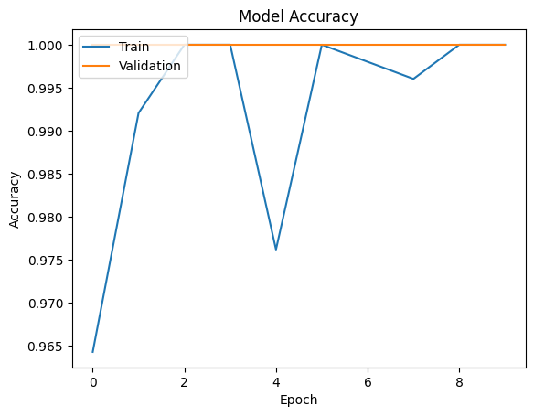

```python
plt.plot(history_3.history['accuracy'])
plt.plot(history_3.history['val_accuracy'])
plt.title('Model Accuracy')
plt.ylabel('Accuracy')
plt.xlabel('Epoch')
plt.legend(['Train', 'Validation'], loc='upper left')
plt.show()
```

```python
model_3_train_perf = model_performance_classification(model_3, X_train_normalized,y_train)

print("Train performance metrics")
print(model_3_train_perf)
```

```
16/16 ━━━━━━━━━━━━━━━━━━━━ 3s 169ms/step
Train performance metrics
   Accuracy  Recall  Precision  F1 Score
0       1.0     1.0        1.0       1.0
```

```python
plot_confusion_matrix(model_3,X_train_normalized,y_train)
```

[output not shown]

```
16/16 ━━━━━━━━━━━━━━━━━━━━ 2s 113ms/step
```

```python
model_3_valid_perf = model_performance_classification(model_3, X_val_normalized,y_val)

print("Validation performance metrics")
print(model_3_valid_perf)
```

```
2/2 ━━━━━━━━━━━━━━━━━━━━ 1s 410ms/step
Validation performance metrics
   Accuracy  Recall  Precision  F1 Score
0       1.0     1.0        1.0       1.0
```

```python
plot_confusion_matrix(model_3,X_val_normalized,y_val)
```

[output not shown]

```
2/2 ━━━━━━━━━━━━━━━━━━━━ 0s 124ms/step
```

#### Visualizing the predictions

```python
# For index 2
plt.figure(figsize=(2,2))
plt.imshow(X_val[12])
plt.show()
prediction = model_3.predict(X_val_normalized[2].reshape(1,200,200,3))
predicted_label = prediction[0][0]>0.5  # Extract the predicted class label
print('Predicted Label:', 1 if predicted_label else 0)
# Fix indexing issue in y_val
true_label = y_val.iloc[12]
print('True Label:', true_label)

# For index 33
plt.figure(figsize=(2,2))
plt.imshow(X_val[33])
plt.show()
prediction = model_3.predict(X_val_normalized[2].reshape(1,200,200,3))
predicted_label = prediction[0][0]>0.5  # Extract the predicted class label
print('Predicted Label:', 1 if predicted_label else 0)
# Fix indexing issue in y_val
true_label = y_val.iloc[33]
print('True Label:', true_label)
```

[output not shown]

```
1/1 ━━━━━━━━━━━━━━━━━━━━ 0s 65ms/step
Predicted Label: 0
True Label: Label    1
Name: 62, dtype: int64
```

```
1/1 ━━━━━━━━━━━━━━━━━━━━ 0s 64ms/step
Predicted Label: 0
True Label: Label    0
Name: 512, dtype: int64
```

## Model 4: (VGG-16 (Base + FFNN + Data Augmentation)

- In most of the real-world case studies, it is challenging to acquire a large number of images and then train CNNs.
- To overcome this problem, one approach we might consider is **Data Augmentation**.
- CNNs have the property of **translational invariance**, which means they can recognise an object even if its appearance shifts translationally in some way. - Taking this attribute into account, we can augment the images using the techniques listed below
  - Horizontal Flip (should be set to True/False)
  - Vertical Flip (should be set to True/False)
  - Height Shift (should be between 0 and 1)
  - Width Shift (should be between 0 and 1)
  - Rotation (should be between 0 and 180)
  - Shear (should be between 0 and 1)
  - Zoom (should be between 0 and 1) etc.

Remember, **data augmentation should not be used in the validation/test data set**.

```python
model_4 = Sequential()

# Adding the convolutional part of the VGG16 model from above
model_4.add(vgg_model)

# Flattening the output of the VGG16 model because it is from a convolutional layer
model_4.add(Flatten())

#Adding the Feed Forward neural network
model_4.add(Dense(256,activation='relu'))
model_4.add(Dropout(rate=0.4))
model_4.add(Dense(32,activation='relu'))

# Adding a dense output layer
model_4.add(Dense(1, activation='sigmoid'))
```

```python
opt=Adam()
# Compile model
model_4.compile(optimizer=opt,   loss=keras.losses.BinaryCrossentropy(), metrics=["accuracy","Precision"])
```

```python
# Generating the summary of the model
model_4.summary()
```

```
Model: "sequential_4"
```

```
┏━━━━━━━━━━━━━━━━━━━━━━━━━━━━━━━━━━━━━━┳━━━━━━━━━━━━━━━━━━━━━━━━━━━━━┳━━━━━━━━━━━━━━━━━┓
┃ Layer (type)                         ┃ Output Shape                ┃         Param # ┃
┡━━━━━━━━━━━━━━━━━━━━━━━━━━━━━━━━━━━━━━╇━━━━━━━━━━━━━━━━━━━━━━━━━━━━━╇━━━━━━━━━━━━━━━━━┩
│ vgg16 (Functional)                   │ (None, 6, 6, 512)           │      14,714,688 │
├──────────────────────────────────────┼─────────────────────────────┼─────────────────┤
│ flatten_4 (Flatten)                  │ (None, 18432)               │               0 │
├──────────────────────────────────────┼─────────────────────────────┼─────────────────┤
│ dense_7 (Dense)                      │ (None, 256)                 │       4,718,848 │
├──────────────────────────────────────┼─────────────────────────────┼─────────────────┤
│ dropout_1 (Dropout)                  │ (None, 256)                 │               0 │
├──────────────────────────────────────┼─────────────────────────────┼─────────────────┤
│ dense_8 (Dense)                      │ (None, 32)                  │           8,224 │
├──────────────────────────────────────┼─────────────────────────────┼─────────────────┤
│ dense_9 (Dense)                      │ (None, 1)                   │              33 │
└──────────────────────────────────────┴─────────────────────────────┴─────────────────┘
```

```
 Total params: 19,441,793 (74.16 MB)
```

```
 Trainable params: 4,727,105 (18.03 MB)
```

```
 Non-trainable params: 14,714,688 (56.13 MB)
```

```python
# Applying data augmentation
train_datagen = ImageDataGenerator(
                              rotation_range=20,
                              fill_mode='nearest',width_shift_range=0.2,height_shift_range=0.2,shear_range=0.3,zoom_range=0.4
                              )
```

```python
history_4 = model_4.fit(train_datagen.flow(X_train_normalized,y_train,
                                       batch_size=8,
                                       seed=42,
                                       shuffle=False),
                    epochs=epochs,
                    steps_per_epoch=X_train_normalized.shape[0] // batch_size,
                    validation_data=(X_val_normalized,y_val),
                    verbose=1)
```

```
63/63 ━━━━━━━━━━━━━━━━━━━━ 14s 141ms/step - Precision: 0.8632 - accuracy: 0.8515 - loss: 0.3739 - val_Precision: 1.0000 - val_accuracy: 1.0000 - val_loss: 8.9863e-06
63/63 ━━━━━━━━━━━━━━━━━━━━ 5s 84ms/step - Precision: 0.9801 - accuracy: 0.9766 - loss: 0.1099 - val_Precision: 1.0000 - val_accuracy: 1.0000 - val_loss: 8.7773e-08
63/63 ━━━━━━━━━━━━━━━━━━━━ 10s 84ms/step - Precision: 1.0000 - accuracy: 1.0000 - loss: 0.0012 - val_Precision: 1.0000 - val_accuracy: 1.0000 - val_loss: 1.4015e-08
63/63 ━━━━━━━━━━━━━━━━━━━━ 6s 98ms/step - Precision: 0.9889 - accuracy: 0.9836 - loss: 0.0650 - val_Precision: 1.0000 - val_accuracy: 1.0000 - val_loss: 1.0212e-06
63/63 ━━━━━━━━━━━━━━━━━━━━ 10s 98ms/step - Precision: 1.0000 - accuracy: 0.9982 - loss: 0.0068 - val_Precision: 1.0000 - val_accuracy: 1.0000 - val_loss: 6.5148e-08
63/63 ━━━━━━━━━━━━━━━━━━━━ 10s 99ms/step - Precision: 0.9903 - accuracy: 0.9863 - loss: 0.0410 - val_Precision: 1.0000 - val_accuracy: 1.0000 - val_loss: 1.2563e-07
63/63 ━━━━━━━━━━━━━━━━━━━━ 9s 85ms/step - Precision: 0.9952 - accuracy: 0.9949 - loss: 0.0303 - val_Precision: 1.0000 - val_accuracy: 1.0000 - val_loss: 3.4231e-07
63/63 ━━━━━━━━━━━━━━━━━━━━ 10s 86ms/step - Precision: 0.9863 - accuracy: 0.9828 - loss: 0.0417 - val_Precision: 1.0000 - val_accuracy: 1.0000 - val_loss: 9.7877e-06
63/63 ━━━━━━━━━━━━━━━━━━━━ 10s 84ms/step - Precision: 0.9991 - accuracy: 0.9996 - loss: 0.0033 - val_Precision: 1.0000 - val_accuracy: 1.0000 - val_loss: 4.5004e-04
63/63 ━━━━━━━━━━━━━━━━━━━━ 6s 94ms/step - Precision: 0.9936 - accuracy: 0.9869 - loss: 0.0245 - val_Precision: 1.0000 - val_accuracy: 1.0000 - val_loss: 3.8729e-07
```

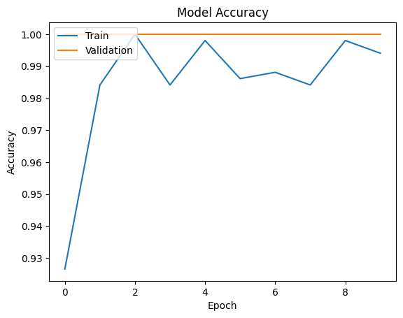

```python
plt.plot(history_4.history['accuracy'])
plt.plot(history_4.history['val_accuracy'])
plt.title('Model Accuracy')
plt.ylabel('Accuracy')
plt.xlabel('Epoch')
plt.legend(['Train', 'Validation'], loc='upper left')
plt.show()
```

```python
model_4_train_perf = model_performance_classification(model_4, X_train_normalized,y_train)

print("Train performance metrics")
print(model_4_train_perf)
```

```
16/16 ━━━━━━━━━━━━━━━━━━━━ 3s 143ms/step
Train performance metrics
   Accuracy  Recall  Precision  F1 Score
0       1.0     1.0        1.0       1.0
```

```python
plot_confusion_matrix(model_4,X_train_normalized,y_train)
```

[output not shown]

```
16/16 ━━━━━━━━━━━━━━━━━━━━ 2s 113ms/step
```

```python
model_4_valid_perf = model_performance_classification(model_4, X_val_normalized,y_val)

print("Validation performance metrics")
print(model_4_valid_perf)
```

```
2/2 ━━━━━━━━━━━━━━━━━━━━ 0s 343ms/step
Validation performance metrics
   Accuracy  Recall  Precision  F1 Score
0       1.0     1.0        1.0       1.0
```

```python
plot_confusion_matrix(model_4,X_val_normalized,y_val)
```

[output not shown]

```
2/2 ━━━━━━━━━━━━━━━━━━━━ 0s 125ms/step
```

#### Visualizing the predictions

```python
# For index 2
plt.figure(figsize=(2,2))
plt.imshow(X_val[12])
plt.show()
prediction = model_4.predict(X_val_normalized[2].reshape(1,200,200,3))
predicted_label = prediction[0][0]>0.5  # Extract the predicted class label
print('Predicted Label:', 1 if predicted_label else 0)
# Fix indexing issue in y_val
true_label = y_val.iloc[12]
print('True Label:', true_label)

# For index 33
plt.figure(figsize=(2,2))
plt.imshow(X_val[33])
plt.show()
prediction = model_4.predict(X_val_normalized[2].reshape(1,200,200,3))
predicted_label = prediction[0][0]>0.5  # Extract the predicted class label
print('Predicted Label:', 1 if predicted_label else 0)
# Fix indexing issue in y_val
true_label = y_val.iloc[33]
print('True Label:', true_label)
```

[output not shown]

```
1/1 ━━━━━━━━━━━━━━━━━━━━ 0s 81ms/step
Predicted Label: 0
True Label: Label    1
Name: 62, dtype: int64
```

```
1/1 ━━━━━━━━━━━━━━━━━━━━ 0s 166ms/step
Predicted Label: 0
True Label: Label    0
Name: 512, dtype: int64
```

# **Model Performance Comparison and Final Model Selection**

```python
# training performance comparison

models_train_comp_df = pd.concat(
    [
        model_1_train_perf.T,
        model_2_train_perf.T,
        model_3_train_perf.T,
        model_4_train_perf.T,
    ],
    axis=1,
)
models_train_comp_df.columns = [
    "Simple Convolutional Neural Network (CNN)","VGG-16 (Base)","VGG-16 (Base+FFNN)","VGG-16 (Base+FFNN+Data Aug)"
]
```

```python
models_valid_comp_df = pd.concat(
    [
        model_1_valid_perf.T,
        model_2_valid_perf.T,
        model_3_valid_perf.T,
        model_4_valid_perf.T

    ],
    axis=1,
)
models_valid_comp_df.columns = [
 "Simple Convolutional Neural Network (CNN)","VGG-16 (Base)","VGG-16 (Base+FFNN)","VGG-16 (Base+FFNN+Data Aug)"
]
```

```python
models_train_comp_df
```

|  | Simple Convolutional Neural Network (CNN) | VGG-16 (Base) | VGG-16 (Base+FFNN) | VGG-16 (Base+FFNN+Data Aug) |
| --- | --- | --- | --- | --- |
| Accuracy | 0.994048 | 1.0 | 1.0 | 1.0 |
| Recall | 0.994048 | 1.0 | 1.0 | 1.0 |
| Precision | 0.994056 | 1.0 | 1.0 | 1.0 |
| F1 Score | 0.994048 | 1.0 | 1.0 | 1.0 |

```python
models_valid_comp_df
```

|  | Simple Convolutional Neural Network (CNN) | VGG-16 (Base) | VGG-16 (Base+FFNN) | VGG-16 (Base+FFNN+Data Aug) |
| --- | --- | --- | --- | --- |
| Accuracy | 0.968254 | 1.0 | 1.0 | 1.0 |
| Recall | 0.968254 | 1.0 | 1.0 | 1.0 |
| Precision | 0.970121 | 1.0 | 1.0 | 1.0 |
| F1 Score | 0.968206 | 1.0 | 1.0 | 1.0 |

```python
models_train_comp_df - models_valid_comp_df
```

|  | Simple Convolutional Neural Network (CNN) | VGG-16 (Base) | VGG-16 (Base+FFNN) | VGG-16 (Base+FFNN+Data Aug) |
| --- | --- | --- | --- | --- |
| Accuracy | 0.025794 | 0.0 | 0.0 | 0.0 |
| Recall | 0.025794 | 0.0 | 0.0 | 0.0 |
| Precision | 0.023934 | 0.0 | 0.0 | 0.0 |
| F1 Score | 0.025842 | 0.0 | 0.0 | 0.0 |

- All the models have achieved high performance.
- However, the last model, which was trained with data augmentation, is likely to generalize better since it has been exposed to a variety of images.

## Test Performance

```python
model_4_test_perf = model_performance_classification(model_4, X_test_normalized,y_test)
```

```
2/2 ━━━━━━━━━━━━━━━━━━━━ 0s 171ms/step
```

```python
model_4_test_perf
```

|  | Accuracy | Recall | Precision | F1 Score |
| --- | --- | --- | --- | --- |
| 0 | 1.0 | 1.0 | 1.0 | 1.0 |

```
2/2 ━━━━━━━━━━━━━━━━━━━━ 0s 127ms/step
```

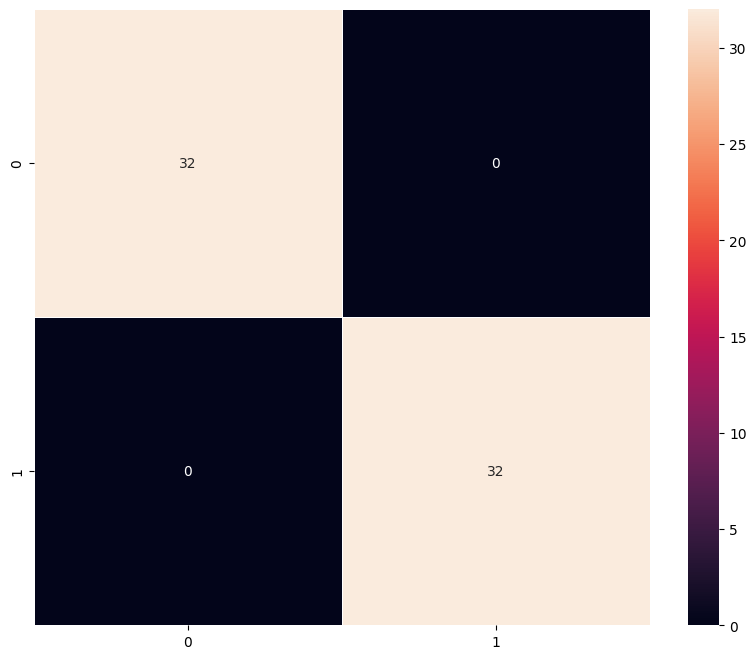

```python
plot_confusion_matrix(model_4, X_test_normalized,y_test)
```

- It has achieved a solid performance in the test set also.

# **Actionable Insights & Recommendations**

- All the models achieved high performance on both the training and validation sets. The best-performing model also achieved a perfect score on the test set.
- The gap between the training and validation performance for some models was slightly noisy but eventually converged.
- The dataset could be trivial. Hence, it should be captured under more realistic conditions.
- Since all the models achieved very high performance, the model trained with data augmentation should be used as it is likely to generalize better.